# Clustering Friendships: A Network Analysis of Friendships Among the French Financial Elite

Fabian Hofmann

12/23/2021

# 1. Theoretical Framework

## 1.1. Research Question and Motivation

*What explains friendship ties within the illustrious inner circle of the French financial elite?* In this blog post, I replicate part of Charles Kadushin’s ([1995](https://www.jstor.org/stable/2096384)) study, which found that elite members who possessed the same level of prestige and lived in the prestigious 16th Arrondissement in Paris were more likely to be friends. Building on the classical work of Simmel ([1950](https://books.google.ch/books?hl=en&lr=lang_en&id=Ha2aBqS415YC&oi=fnd&pg=PR17&ots=ONOp7-Fq3R&sig=Zte2bK7tqpdTDjSi8tLK_4iPQgg&redir_esc=y#v=onepage&q&f=false)) on social triads as well as Holland & Leinhardt ([1971](https://doi.org/10.1177/104649647100200201)), who demonstrated that friendships are overwhelmingly transitive, I extend Kadushin’s conceptual focus on status homophily by including clustering effects as a structure-related explanatory variable.

## 1.2. Hypotheses

Structure-related:

- **H1:** Friendship ties between members of the French financial elite tend to be clustered.

Prestige-related:

- **H2:** The number of friendship ties between elite members differs across prestige levels.
- **H3:** Members of the financial elite with the same prestige level are more likely to form friendship ties than members with differing prestige levels.

Residence-related:

- **H4:** Residence in the 16th Arrondissement affects friendship formation rates within the financial elite.
- **H5:** Residents of the 16th Arrondissement have a higher probability of forming friendship ties amongst themselves than with members residing in other areas.

# 2. Methodology and Modeling Choices

## 2.1. Data and Visualization

Charles Kadushin ([1995](https://www.jstor.org/stable/2096384)), collected data on 125 members of the French financial elite in 1990, which he recruited through a snowball sampling technique. Using an “aggregate prominence measure” ([Burt 1982](https://www.sciencedirect.com/book/9780121471507/toward-a-structural-theory-of-action#book-info)), he identified the 28 individuals belonging to the elite inner circle and interviewed them on their friendship ties and individual attributes. Friendship was treated as a symmetric relationship, and thus his original network contains 181 undirected ties between 28 elite members. For this blog post, three nodes without residence information had to be excluded from the analysis because retaining them in the sample would have biased the results. Therefore, the network employed here, which is displayed in Figure 1, only contains **25 nodes and 132 edges**:

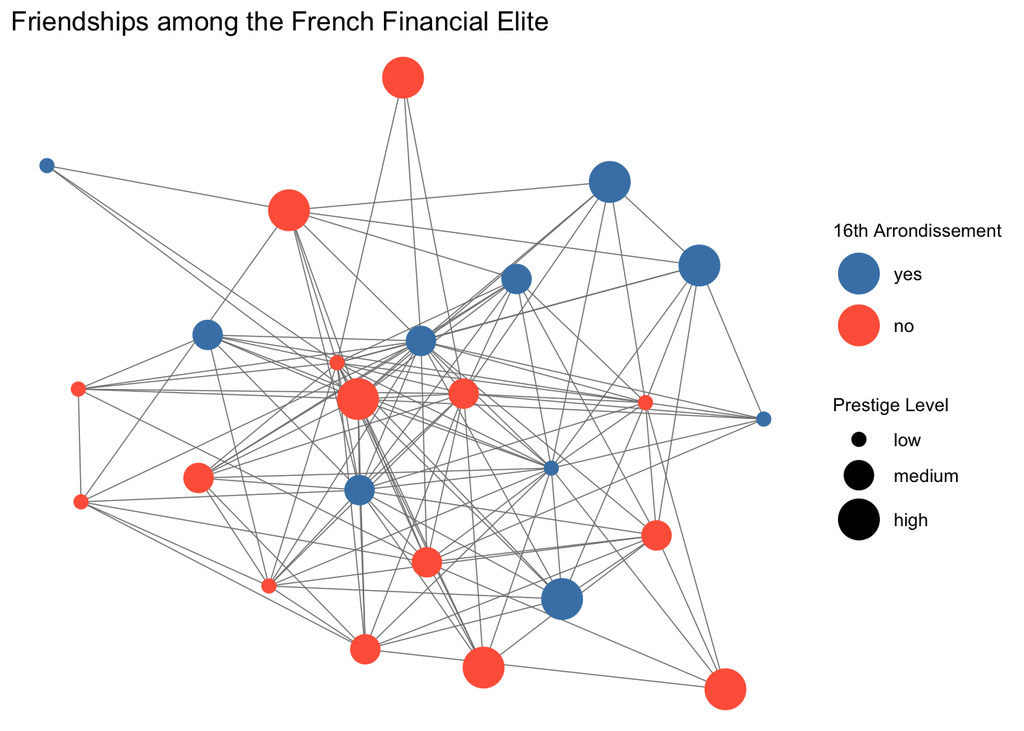

In terms of network configurations, the friendship network comprises a densely connected main component without isolates. Both density and transitivity are very high in the network, with 0.44 and 0.55, respectively. This points to the importance of network self-organizing effects in tie formation.

## 2.2. Network Modeling and Specification

In his study, Kadushin ([1995](https://www.jstor.org/stable/2096384)) used a Multiple Regression Quadratic Assignment Procedure (MRQAP) to control for network dependencies. Using an Exponential-Family Random Graph model (ERGM), this blog post extends his analysis by explicitly modeling clustering as a structural network effect, instead of just controlling for it. ERGMs can be used to specify the tie probability distribution for a set of random graphs while modeling specific network dependencies ([statnet 2021](https://cran.r-project.org/web/packages/ergm/vignettes/ergm.pdf)).

- A **structural-only model** was estimated using *gwesp* with an alpha of 0.25 to capture clustering effects.
- To infer whether nodal attributes influence friendship formation rates (H2/H4), the ergm term *nodefactor* was included in a **covariates-added model** alongside the term *nodematch* to investigate attribute-related homophily (H3/H5).

# 3. Discussion of Results

## 3.1. Model Outputs and Interpretation

Overall, the structural-only model exhibits a higher Akaike Information Criterion (AIC) value than the covariates-added model, indicating that the latter fits the data better. As shown in the table, clustering and low prestige have positive coefficients significant at the 0.05 level; medium prestige is even highly significant at the 0.001 level. In contrast, the *nodematch* terms capturing prestige and residence homophily produced insignificant coefficients. From these values, it follows that:

- **H1 cannot be rejected** at the 0.05 level, which indicates that clustering effects are present in the network. Once a new edge is added to the network, the likelihood of one new triangle forming, considering a nodes’ existing ties, is 2.14%. The chance of two new triangles forming lies at 98.11%.
- The positive and statistically significant coefficients for low and medium prestige suggest that these prestige levels increase the probability of friendship ties forming, and hence **H2 cannot be rejected** either.
- **H3 can be refuted** because the coefficients suggest no statistically significant difference in friendship formation between elite members with the same or different prestige levels.
- Residence in the 16th Arrondissement has no statistically significant impact on friendship formation rates, and so **H4 can be rejected** as well.
- Likewise, the results show no statistically significant effects for homophily by shared residence in the 16th Arrondissement, and accordingly, **H5 can be refuted**.

Table 1: ERGM of the Structural-Only and Covariates-Added Models: friends.ergm.cov <- ergm(friends ~ edges + gwesp(0.25, fixed = T) + nodefactor(prestige) + nodematch(prestige) + nodefactor(arond16) + nodematch(arond16), control=control.ergm(MCMC.interval=1, MCMC.burnin=1000, seed=1), verbose = T)

|  | Structural-Only | Covariates-Added |
| --- | --- | --- |
| edges | -12.85* | -11.60* |
|  | (5.94) | (4.95) |
| gwesp.fixed.0.25 | 9.29* | 7.77* |
|  | (4.49) | (3.76) |
| nodefactor.prestige.low |  | 0.44* |
|  |  | (0.21) |
| nodefactor.prestige.medium |  | 0.77*** |
|  |  | (0.22) |
| nodematch.prestige |  | 0.05 |
|  |  | (0.28) |
| nodefactor.arond16.yes |  | -0.02 |
|  |  | (0.17) |
| nodematch.arond16 |  | -0.05 |
|  |  | (0.25) |
| AIC | 403.62 | 398.73 |
| BIC | 411.03 | 424.66 |
| Log Likelihood | -199.81 | -192.37 |

***p < 0.001; **p < 0.01; *p < 0.05

## 3.2. Model diagnostics using MCMC and GOF

Markov Chain Monte Carlo (MCMC):

The model diagnostics using MCMC confirm the relative robustness of the results. Sample statistic auto-correlation values are close to 0, indicating that the MCMC chain is randomly mixing and not headed off in the wrong direction. Similarly, the differences between observed and simulated values displayed in the MCMC density plots follow a quasi-normal distribution centered around 0.

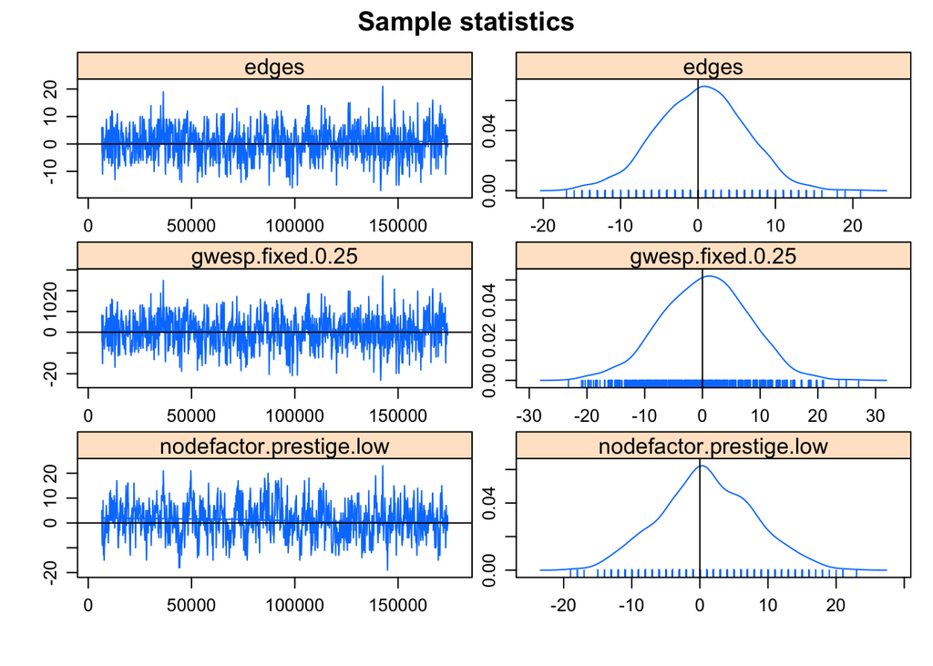

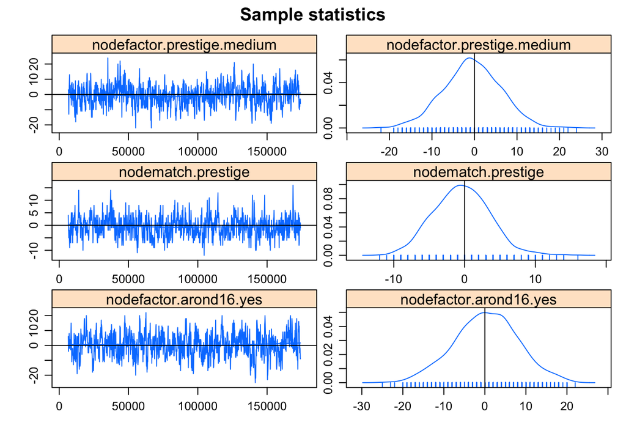

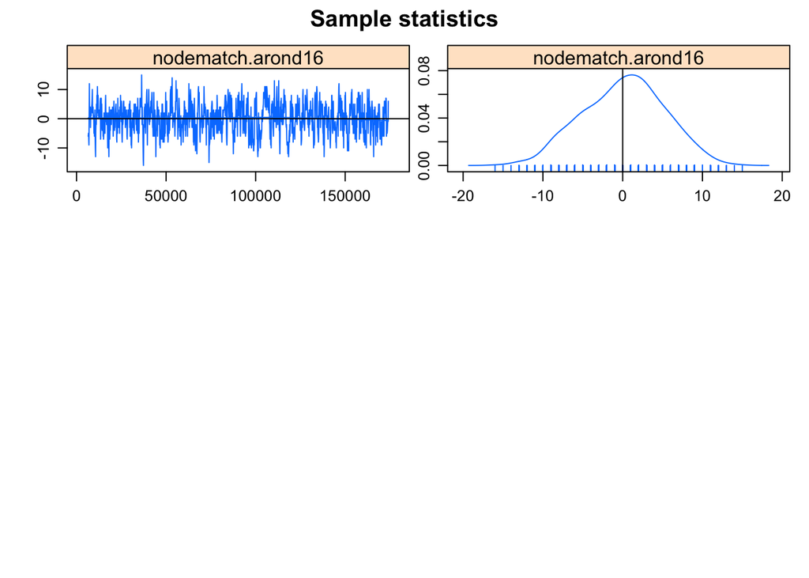

[output not shown]

Goodness-of-fit (GOF):

The GOF diagnostics reveal that the model performs relatively well in estimating the theoretically most salient network statistics, namely the model statistics and the triad census. However, the model fails to correctly estimate the degree distribution and the number of edge-wise shared partners, both over- and underestimating the statistics of the observed network. According to these diagnostics, the model parameters do not closely resemble the observed values, which casts doubt on the finding’s accuracy and robustness.

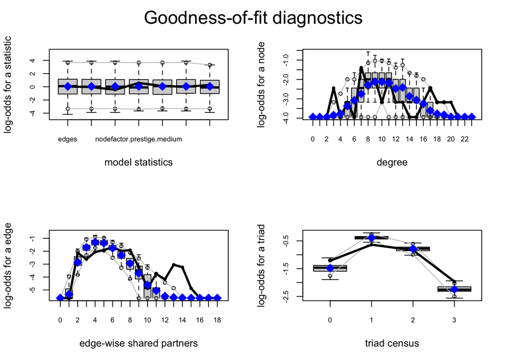

# 3. Conclusion

The extension of Kadushin’s ([1995](https://www.jstor.org/stable/2096384)) analysis has shown that clustering and prestige significantly influence friendship formation rates within the French financial elite. However, homophily in friendships by prestige and residence could not be established, which questions the robustness of Kadushin’s findings. To corroborate the results of the analysis presented here, more sophisticated modelling techniques that produce models with a better fit for the data should be employed. For instance, future studies on elite networks could collect panel or time-stamped data to make inferences about friendship dynamics and use SAOMs or DyNAMs to specify actor-oriented models for elite friendship formation. However, data collection on elite networks might prove challenging, due to researchers’ restricted access to these circles.